# Introdução à Linguagem R

## 3.4 Estruturas de dados

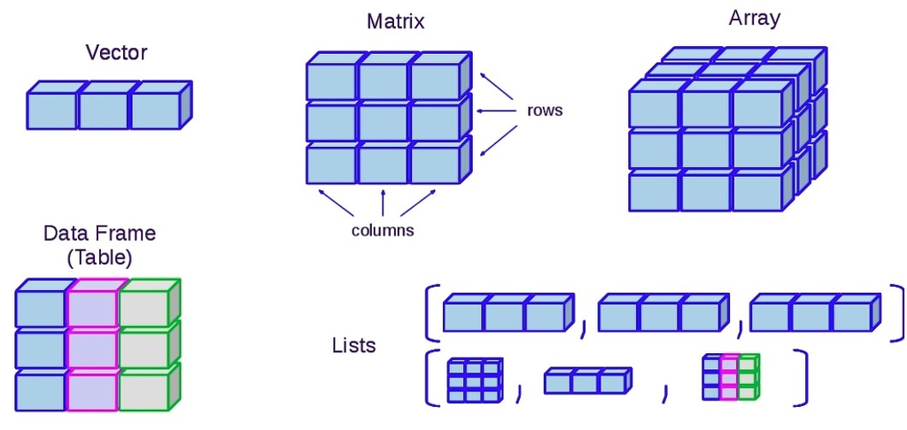

### 3.4.1 Vetores

```r
x<-c(40,66,51,10,12)
class(x)
```

```
## [1] "numeric"
```

```r
length(x)
```

```
## [1] 5
```

```r
str(x)
```

```
##  num [1:5] 40 66 51 10 12
```

```r
x[2]
```

```
## [1] 66
```

```r
x[1:3]
```

```
## [1] 40 66 51
```

```r
x[x<50]
```

```
## [1] 40 10 12
```

#### 3.4.1.1 Criando vetores com sequências

- rep(x, vezes)
- seq(de, até, incremento(by)/extensão(length))

```r
x3 <- 1:10
x4 <- seq(0,10, by=2)
x4[x4<5]
```

```
## [1] 0 2 4
```

```r
x4<5
```

```
## [1]  TRUE  TRUE  TRUE FALSE FALSE FALSE
```

```r
x <- c(0:10, 50)
seq(0,10, length=11)
```

```
##  [1]  0  1  2  3  4  5  6  7  8  9 10
```

```r
rep(1,times = 5)
```

```
## [1] 1 1 1 1 1
```

```r
rep(1,5)  # mesmo que rep(1,times = 5)
```

```
## [1] 1 1 1 1 1
```

O comando `rep(x, times, each, length)` repete os elementos de x vezes (times). A seguir, primeiramente, o comando repete o número 1 duas vezes. Depois, repete a sequencia de 1 a 3 duas vezes. Finalmente, repete o número 1 três vezes e o número 2 cinco vezes.

```r
rep(1, times=2)
```

```
## [1] 1 1
```

```r
rep(1:3, times=2)
```

```
## [1] 1 2 3 1 2 3
```

```r
rep(c(1,2),times=c(3,5))
```

```
## [1] 1 1 1 2 2 2 2 2
```

```r
rep(1:3, rep(2,3))
```

```
## [1] 1 1 2 2 3 3
```

Com o argumento `each`, primeiro se repete depois se passa para o próximo número de **x**. Note a diferença desta instrução para a anterior, `rep(1:3, times=2)`.

```r
rep(1:3, each = 2)
```

```
## [1] 1 1 2 2 3 3
```

```r
rep(1:3, each = 2, len = 4)    # somente os 4 primeiros.
```

```
## [1] 1 1 2 2
```

Veja os comandos a seguir.

```r
rep(1:3,times=5)
```

```
##  [1] 1 2 3 1 2 3 1 2 3 1 2 3 1 2 3
```

```r
rep(1:3,rep(5))
```

```
##  [1] 1 2 3 1 2 3 1 2 3 1 2 3 1 2 3
```

```r
rep(1:3,rep(5,3))  # mesmo que rep(1:3, each=5)
```

```
##  [1] 1 1 1 1 1 2 2 2 2 2 3 3 3 3 3
```

```r
rep(1:3,5)
```

```
##  [1] 1 2 3 1 2 3 1 2 3 1 2 3 1 2 3
```

É possível controlar a repetição de cada elemento de x usando `c()`

```r
rep(1:4, times= c(2,2,2,2))     # igual a each=2
```

```
## [1] 1 1 2 2 3 3 4 4
```

```r
rep(1:4, times= c(2,3,4,2))     # repetição variada para cada elemento de x
```

```
##  [1] 1 1 2 2 2 3 3 3 3 4 4
```

Pode-se controlar a extensão dos resultados com `length` ou `len`.

```r
rep(1:4, each = 2, len = 4)    # repete 2x cada até completar 4 elementos
```

```
## [1] 1 1 2 2
```

O R recicla os elementos até completar a extensão desejada

```r
rep(1:4, each = 2, len = 10)   # 2x cada até completar 10 elementos
```

```
##  [1] 1 1 2 2 3 3 4 4 1 1
```

```r
rep(1:4, each = 2, times = 3)  # extensão 24, 3 reciclagens completas
```

```
##  [1] 1 1 2 2 3 3 4 4 1 1 2 2 3 3 4 4 1 1 2 2 3 3 4 4
```

### 3.4.2 Data-frames

Um Data-frame é uma lista de variáveis com a mesma extensão.

```r
df<-data.frame("estado"=c("Pará", "Amazonas","Roraima"),
               "sigla"=c("PA","AM","RR"),
               "num.empresas"=c(2,4,3))
df
```

```
##     estado sigla num.empresas
## 1     Pará    PA            2
## 2 Amazonas    AM            4
## 3  Roraima    RR            3
```

```r
df$estado     # variável
```

```
## [1] "Pará"     "Amazonas" "Roraima"
```

```r
df[2]         # variável
```

```
##   sigla
## 1    PA
## 2    AM
## 3    RR
```

```r
df[3,2]       # elemento
```

```
## [1] "RR"
```

```r
df$estado[1]  # elemento
```

```
## [1] "Pará"
```

```r
names(df)
```

```
## [1] "estado"       "sigla"        "num.empresas"
```

```r
str(df)
```

```
## 'data.frame':    3 obs. of  3 variables:
##  $ estado      : chr  "Pará" "Amazonas" "Roraima"
##  $ sigla       : chr  "PA" "AM" "RR"
##  $ num.empresas: num  2 4 3
```

```r
# Data frame a partir de outros objetos
fornecedor<-rep(c("A","B"), each=3)
fornecedor
```

```
## [1] "A" "A" "A" "B" "B" "B"
```

```r
valor<-c(100,200,150,300,100,200)
data.frame(fornecedor,valor)
```

```
##   fornecedor valor
## 1          A   100
## 2          A   200
## 3          A   150
## 4          B   300
## 5          B   100
## 6          B   200
```

### 3.4.3 lists

As listas (*lists*) são objetos com outros objetos que podem ser de diversas classes e de diferentes dimensões. Para referenciar um membro da lista, usa-se duplos colchetes “[[]]”.

```r
numeros <- c(1, 2, 3)                  # numeric
nomes <- c("Joao", "Maria")            # character
testes <- c(TRUE, FALSE, FALSE, FALSE) # logic
x <- list(numeros, nomes, testes)
x
```

```
## [[1]]
## [1] 1 2 3
##
## [[2]]
## [1] "Joao"  "Maria"
##
## [[3]]
## [1]  TRUE FALSE FALSE FALSE
```

```r
x[[2]]
```

```
## [1] "Joao"  "Maria"
```

```r
x[[2]][1]
```

```
## [1] "Joao"
```

### 3.4.4 tibbles

A tibble são estruturas de dados que se parecem com data.frames, mas com recursos adicionais, constituindo uma evolução dos data frames para um apresentação mais amigável.

Essa estrutura de dados pertence ao pacote tibble que, por sua vez, está incluso no populares pacotes tidyr e tidyverse. Na demonstração a seguir, caso ainda não tenha tenha sido instalado nenhum desses pacotes, será necessário instalar apenas o primeiro, `install.packages(“tibble”).

As formas mais comuns de se criar tibbles são por meio da função `tibble()` e por conversão de um objeto com a função `as_tibble()`.

```r
library(tibble)

tibble(
  a = c(2,2,2),
  b = c(1,2,3))
```

```
## # A tibble: 3 × 2
##       a     b
##   <dbl> <dbl>
## 1     2     1
## 2     2     2
## 3     2     3
```

```r
df <- data.frame(
  a = c(2,2,2),
  b = c(1,2,3))


class(df)
```

```
## [1] "data.frame"
```

```r
tb <- as_tibble(df) # convertendo
class(tb)
```

```
## [1] "tbl_df"     "tbl"        "data.frame"
```

Como as tibbles são alternativas mais avançadas dos que os data frames, os demonstrações a seguir enfatizam as distições entras as estuturas de dados.

As tibbles permitemtem que os nomes das colunas usem formatos não válidos no R, não precisam iniciar com letras, podem conter caracteres como o espaço, ou serem números, caso estejam escritas entre acentos agudos.

Exite a altertiva de se utilizar o `tribble()` (*transposed tibble*) para se entrar com dados, com os nomes das variáveis no topo, definidas por “~” e as colunas de dados separadas por vírgulas.

```r
tb <- tibble(
   `:)` = "sorria",
   ` ` = "espaços",
   `2020` = "um número")
tb
```

```
## # A tibble: 1 × 3
##   `:)`   ` `     `2020`
##   <chr>  <chr>   <chr>
## 1 sorria espaços um número
```

```r
tribble(
   ~Obs, ~a, ~b,
   #--|--|----
   "obs. 1", 2, 1,
   "obs. 2", 2, 2,
   "obs. 3", 2, 3
 )
```

```
## # A tibble: 3 × 3
##   Obs        a     b
##   <chr>  <dbl> <dbl>
## 1 obs. 1     2     1
## 2 obs. 2     2     2
## 3 obs. 3     2     3
```

Uma outra vantagem muito interessante da tibble em relação ao data frame é que a primeira é criada senquencialmente, permitindo criar colunas com base em dados disponíveis em colunas anteriores, enquanto, no data frame, isso não é possível por ser criado em bloco, logo não é possível, num único passo, criar uma coluna com base em dados de colunas criadas na mesma função.

```r
data.frame(
  a = c(2,2,2),
  b = c(1,2,3),
  soma = a+b)
```

```
## Error in data.frame(a = c(2, 2, 2), b = c(1, 2, 3), soma = a + b) : object 'a' not found
```

Não foi possível executar a função porque a coluna `soma` exige dados em colunas ainda não criadas.

Para inserir a terceiras coluna no data frame, é necessária uma etapa acidional.

```r
df <- data.frame(
  a = c(2,2,2),
  b = c(1,2,3))

df$soma <- df$a+ df$b
df
```

```
##   a b soma
## 1 2 1    3
## 2 2 2    4
## 3 2 3    5
```

Já no caso da tibble, **a** e **b** são criadas antes da **soma**, permitindo a criação desta com base nas colunas criadas anteriormente.

```r
tibble(
  a = c(2,2,2),
  b = c(1,2,3),
  soma = a+b)
```

```
## # A tibble: 3 × 3
##       a     b  soma
##   <dbl> <dbl> <dbl>
## 1     2     1     3
## 2     2     2     4
## 3     2     3     5
```

Uma diferença marcante na exibição dos dados de uma tibble em relação aos data frames é a sua capacidade de ajustar ao console enquanto o data frame exibe todos os dados poluindo a janela quando há granda quantidade de observações. Para exmplificar, a diferença entre ambos, tome-se o banco de dados iris que disponível no R, que está originalmente armazenado em forma de data frame e exibi-lo também após ser convertido em tibble.

O iris é um banco de dados com 150 observações e, para economizar espaço neste texto, serão exibidas somente as 20 primeiras, mas, no computador do usuário serão exibidas as 150 quando o data frame iris for chamado no console.

```r
data("iris")
class(iris)
iris
```

```
## [1] "data.frame"
```

```
##    Sepal.Length Sepal.Width Petal.Length Petal.Width Species
## 1           5.1         3.5          1.4         0.2  setosa
## 2           4.9         3.0          1.4         0.2  setosa
## 3           4.7         3.2          1.3         0.2  setosa
## 4           4.6         3.1          1.5         0.2  setosa
## 5           5.0         3.6          1.4         0.2  setosa
## 6           5.4         3.9          1.7         0.4  setosa
## 7           4.6         3.4          1.4         0.3  setosa
## 8           5.0         3.4          1.5         0.2  setosa
## 9           4.4         2.9          1.4         0.2  setosa
## 10          4.9         3.1          1.5         0.1  setosa
## 11          5.4         3.7          1.5         0.2  setosa
## 12          4.8         3.4          1.6         0.2  setosa
## 13          4.8         3.0          1.4         0.1  setosa
## 14          4.3         3.0          1.1         0.1  setosa
## 15          5.8         4.0          1.2         0.2  setosa
## 16          5.7         4.4          1.5         0.4  setosa
## 17          5.4         3.9          1.3         0.4  setosa
## 18          5.1         3.5          1.4         0.3  setosa
## 19          5.7         3.8          1.7         0.3  setosa
## 20          5.1         3.8          1.5         0.3  setosa
```

Após conversão em tibble, a exibição se limita a um máximo de 10 observações e com as colunas ajustadas ao console do usuário. A apresentação do número de oservações não exibidas vem no final.

```r
iristb <- as_tibble(iris) # conversão
iristb
```

```
## # A tibble: 150 × 5
##    Sepal.Length Sepal.Width Petal.Length Petal.Width Species
##           <dbl>       <dbl>        <dbl>       <dbl> <fct>
##  1          5.1         3.5          1.4         0.2 setosa
##  2          4.9         3            1.4         0.2 setosa
##  3          4.7         3.2          1.3         0.2 setosa
##  4          4.6         3.1          1.5         0.2 setosa
##  5          5           3.6          1.4         0.2 setosa
##  6          5.4         3.9          1.7         0.4 setosa
##  7          4.6         3.4          1.4         0.3 setosa
##  8          5           3.4          1.5         0.2 setosa
##  9          4.4         2.9          1.4         0.2 setosa
## 10          4.9         3.1          1.5         0.1 setosa
## # … with 140 more rows
```

Algumas funções construídas para data frames podem não funcionar com tibbles e a razão está no fato de que, na maioria das vezes, o data frame retorna vetores de dados numéricos ou alfanuméricos, quando são chamados, enquanto que uma tible retorna uma tibble na maioria das chamadas de dados, de modo que a estrutura de dados recebida pela função pode ser a esperada, conduzindo ao erro de execução.

A seguir serão demonstradas as estruturas de dados retornados por data frames e tibbles conforme o tipo de chamada de dados. Primeiro são criados dois banco de dados no formato data frame e no formato tibble, depois, a coluna **a** é chamada de diversas maneiras e indicando a classe do respectivo retorno

```r
# data frame
df <- data.frame(
  a = c(2,2,2),
  b = c(1,2,3))

# tibble
tb <- tibble(
  a = c(2,2,2),
  b = c(1,2,3))

df
```

```
##   a b
## 1 2 1
## 2 2 2
## 3 2 3
```

```r
tb
```

```
## # A tibble: 3 × 2
##       a     b
##   <dbl> <dbl>
## 1     2     1
## 2     2     2
## 3     2     3
```

```r
df[,1]
```

```
## [1] 2 2 2
```

```r
tb[,1]
```

```
## # A tibble: 3 × 1
##       a
##   <dbl>
## 1     2
## 2     2
## 3     2
```

A seguir, são demonstradas as chamadas de coluna de data frame que retornam vetores numéricos ou alfanuméricos.

```r
# Data frame retorna vetor
class(df[,1]) # vetor numeric/sring
```

```
## [1] "numeric"
```

```r
class(df[["a"]]) # vetor numeric/sring
```

```
## [1] "numeric"
```

Agora as chamadas de coluna de data frame que retornam data frames.

```r
class(df["a"]) # data frame
```

```
## [1] "data.frame"
```

```r
class(df[1]) #  data frame
```

```
## [1] "data.frame"
```

A seguir, são demonstradas as chamadas de coluna de tibble que retornam tibble.

```r
class(tb[,1]) # retorna tibble
```

```
## [1] "tbl_df"     "tbl"        "data.frame"
```

```r
class(tb[1]) #retorna tibble
```

```
## [1] "tbl_df"     "tbl"        "data.frame"
```

```r
class(tb["a"]) #retorna tibble
```

```
## [1] "tbl_df"     "tbl"        "data.frame"
```

Finalmente, as chamadas de coluna de tibble que retornam vetores numéricos ou alfanuméricos.

```r
class(tb[[1]]) # vetor numeric/string
```

```
## [1] "numeric"
```

```r
class(tb$a) # vetor numeric/string
```

```
## [1] "numeric"
```

# 4 Importação e exportação de dados

Dois aspectos importantes a serem observados na importação e exportação de dados são as características do banco de dados e a sua localização.

Se os dados a serem importados estiverem no diretório de trabalho (*Working Directory*) ou se serão salvos nele, não há necessidade de informações adicionais e o arquivo pode ser chamado pelo nome, como **“arquivo.txt”**, do contrário, a sua localização deve ser indicada junto com seu nome, por exemplo, **“C:/usuarios/nome/pasta/arquivo.txt”**.

Atenção para o Windows, utiliza barras investidas para indicar o caminho dos arquivos e diretórios. Logo, se o caminho for copiado do Windows, provavelmente, será colado **“C:\usuarios\nome\pasta\arquivo.txt”**, de forma que as barras precisam ser substitutídas por barras comuns ou utilizar barras investidas duplas: **“C:\ \ usuarios\ \ nome\ \ pasta\ \ arquivo.txt”** para que sejam interpretadas corretamente como caminho pelo R.

Assim, sempre é prudente estar certo da localização de seus dados e de seu diretório de trabalho para não se perder tempo. Seu diretório de trabalho é exibido pelo seguinte comando `getwd()`.

Com relação às características dos dados, deve-se observar o tipo do de arquivo, se estão em formato txt, excel ou outro, e como os dados estão gravados, se possuem rótulos, como estão separados e qual o separador de decimal, vírgula ou ponto.

## 4.1 Importação de dados do excel

### 4.1.1 Usando pacote readxl

Uma maneira mais prática de importação de dados é por meio do pacote **readxl** que permite importação de dados de dados armazenados em txt, Excel, SPSS, SAS e STATA.

Para importar dados em planilhas do Excel na janela, deve-se clicar na botão **Import Dataset**, na aba **Environment** localizada na janela superior direita do terminal do RStudio, e selecionar **From Excel…**

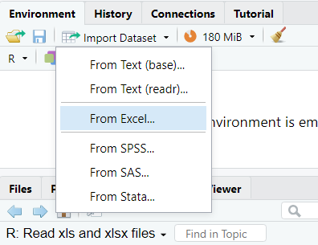

Um janela de navegação é aberta para encontrar o arquivo e abri-lo. O exemplo buscamos o arquivo **aditivo.xlsx** que está no diretório de trabalho atual.

O padrão (*default*) é a exibição dos dados da aba na posição 1 do Excel, no **Data Preview**. Pode ser observado que os dados são constitídos de duas colulas, na primeira linha estão os rótulos das variáveis, **aditivo**, identificada como texto (*character*), e **km** , identificada como numéricas (*double*). No **Data Preview**, pode-se visualizar até 50 observações.

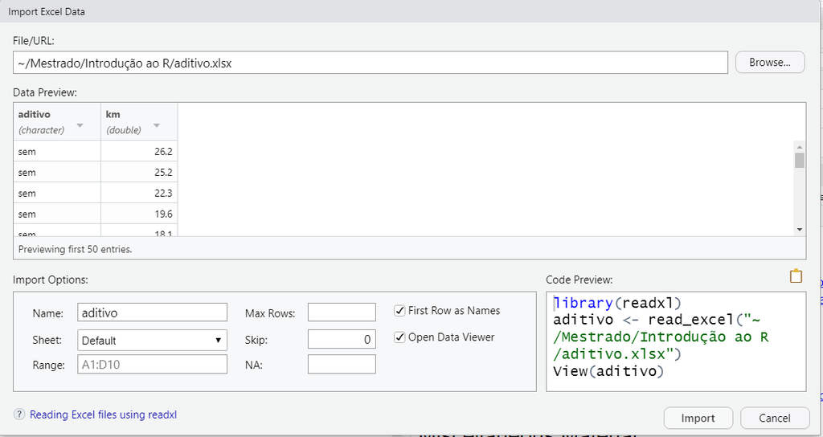

- **Name**: nome do objeto (tibber), para o qual será importado os dados. O padrão é que seja o mesmo nome do arquivo do Excel, mas pode ser alterado, digietando-se diretamente na caixa.
- **Sheet**: aba do Excel em que estão os dados. O padrão é a aba na posição 1, mas para selecionar outra aba, deve-se clicar na guia que um lista das abas do arquivo são exibidas para seleção.
- **Range**: faixa em que estão os dados que, é geralmente identificada automaticamente, podendo ser alterada. No exemplo, os dados estão da célular **A1** até a célula **D10**.
- **Max Rows**: Espaço para indicar o número máximo de linhas desejado. Quando se deseja todos os dados, deve ser deixada em branco.
- **Skip**: Quantas linhas deve pular para iniciar a faixa de dados. No exemplo a faixa de dados, inicia com os os rótulos das variáveis, portanto, não precisa pular nenhuma linha.
- **NA**: Como são indicada as célular sem dados. O padrão é espaço vazio, mas pode vir informado de outra maneira, como “-” ou “N.A.”.
- **First row as Names**: O padrão é esteja selecionada indicando que a primeira linha contenha os nomes das variáveis. Caso contrário, se as variáveis não vierem com seus nomes na primeira linha da feixa, deve ser desmarcada.
- **Open Data Viewer**: Opção para exibir os dados em janela separada.
- **Code Preview**: Exibe o código que será rodado, conforme asa opções escolhidas e que pode ser copiada para ser utilizada em scripts posteriores sem a necessidade de executar todas as etapas novamente.

Para concluir a importação, resta clicar em *Import* que o RStudios cola e executa os comandos no console e exibirá os dados em janela separada se a opção **Open Data Viewer** tiver sido selecionada.

O pacote pomite ainda realizar a importação por meio de código. a sintaxe da função é:

```r
read_excel("caminho do arquivo/arquivo.xlsx")
```

A seguir, são apresentados quatro exemplos, o primeiro supondo que o arquivo do Excel está no diretório de trabalho, e, portanto, sem a necessidade de escrever o cominho; o segundo supondo que o arquivo está num subdiretório do diretório de trabalho; o terceiro com o caminho completo do arquivo; e o quarto, supondo que o arquivo esteja no diretório de trabalho, mas evidenciando alguns argumentos, como a posição da aba no Excel que, no caso, é a primeira (`sheet = 1`), que a primeira linha possui os nomes das variáveis (`col_names = TRUE`) e que os dados ausentes são indicados por células vazias (`na = ""`).

```r
library(readxl)

aditivo1 <- read_excel("aditivo.xlsx")

aditivo2 <- read_excel("dados/aditivo.xlsx")

aditivo3 <- read_excel("C:/Users/aless/OneDrive/Documents/Mestrado/IntroducaoR/aditivo.xlsx")

aditivo4 <- read_excel("aditivo.xlsx", sheet = 1, col_names = TRUE, na = "")
```

### 4.1.2 Copiando

Há várias maneiras de importar dados do excel. Para importar dados do Excel via área de transferência, pode-se utilizar a função `read.table()`, com o argumento `file="clipboard`. Deve-se proceder da seguinte forma:

1. Selecione os dados que você deseja importar, inclusive os nomes das variáveis, e copie para a área de tranferência;
2. No R digite a seguinte instrução:

`dados <- read.table("clipboard", header=TRUE, dec=",")`

Se não selecionar os nomes das variáveis, deve-se ajustar o argumento `header=FALSE`.

Deve-se ter o cuidado para não haver espaços nos dados alfanuméricos, por exemplo, “Universidade Federal”, porque o R entenderá o espaço como quebra de coluna, provocando erro na leitura.

## 4.2 importação de dados no formato R: load

Para importar dados do R com as extensões **.R**, **.rda** ou **.Rdata**, basta utilizar o comando `load()`. Por exemplo para importar os dados do arquivo **desc_morettin.Rdata**.

```r
load("desc_morettin.Rdata")
head(dados)
View(dados)
```

Você pode observar que o arquivo **.Rdata** é capaz de armazenar diversos objetos que são carregados no ambiente de trabalho. A seção 4.5 trata com mais detalhes esse essunto.

No exemplo, os arquivo está no diretório de trabalho; o entanto, caso esteja noutro diretório, deve-se incluir o caminho completo no comando `load("C:/usuarios/nome/pasta/desc_morettin.Rdata")`. Atenção que um erro muito comum entre os usuários iniciantes é o esquecimento das aspas.

## 4.3 importação de dados em arquivos .txt

Para importar arquivos no formato **txt**, use o comando `read.table()`. Caso o arquivo tenha o nome das variável na primeira linha, acrescente o argumento `header=TRUE`, uma vez que o *default* é `FALSE`. Se o separador de decimais for a vírgula, não o ponto, como no padrão americano, deve-se acrescentar argumento `dec=","`.

A seguir são importados os dados do arquivo **notas_AB.txt**:

```r
dados<-read.table("notas_AB.txt", header=TRUE, dec=",")  # ler dados em txt
dados
```

## 4.4 importação de dados em arquivos .csv

Para importar arquivos no formato **csv** (*comma-separated values*), use o comando `read.csv()`. Caso o arquivo tenha os nomes das variável na primeira linha, não precisa acrescentar o argumento `header=TRUE`, já que esse é o *default*. Se o seperador de decimais for a vírgula, e não o ponto, como no padrão americano, deve-se acrescentar argumento `dec=","`.

A seguir são importados os dados do arquivo **notas_AB.csv**:

```r
dados<-read.csv("notas_AB.csv", dec=",") # ler dados em csv
dados
```

## 4.5 Arquivos .Rdata: comandos save e load

O comando `save()` armazena vetores, outros objetos ou mesmo a área de trabalho criados no R num arquivo do tipo **.Rdata**. Os dados podem ser carregados pelo comando `load()` ou clicando no arquivo.

```r
x<-1:10
y<-x^2+10
save(x, y, file = "xy.Rdata")
rm(y,x) # remove objetos
load("xy.Rdata")

save.image("minhaArea.Rdata") # salva a área de trabalho
load("minhaArea.Rdata") # carrega área de trabalho
```

No primeiro exemplo, salvaram-se os objetos **x** e **y** no arquivo **xy.Rdata**. No segundo, todos os objetos da área de trabalho foram salvos no arquivo.

## 4.6 Comandos dump e source

O comando `dump()` salva objetos num documento com extensao **.R** os quais podem ser lidos pelo comando `source()`

```r
cemDados<-1:100 # sequência de 1 a 100
dump("cemDados", file ="cem.R")  # salva objetos listados num arquivo.
rm(cemDados) # Remove objeto da área de trabalho

source("cem.R")                # carrega o arquivo
dump(list=objects(), file ="all.R") # todos os objetos
```

Uma utilidade interessante do comando `dump()` é a chamada de funções, que são sequências de instruções criadas no R. O usuário pode criar uma função e salvar o script para automatizar alguma rotina.

Vamos chamar uma função simples criada para contar a quantidade de elementos num vetor e calcular a média. Denominamos essa função de **minhaFuncao.R**. A seguir, o exemplo:

```r
umvetor<-c(5,7,9)
source("minhaFuncao.R")
minhaFuncao(umvetor)
```

```
## Número de elementos do vetor:  3
## A média do vetor é:  7
```

Para os mais curiosos, a seguir, é apresentado o *script* da função `minhaFuncao.R`

```r
minhaFuncao<-function(x)
{
  n<-length(x)
  media<-mean(x)
  cat("número de elementos do vetor: ",n)
  cat("\nA média do vetor é: ", media)
  }
```

## 4.7 Comandos write.table, read.table, write.csv e write.csv2

O comando `write.table()` permite a exportação de dados para vários formatos de arquivos. O argumento `sep =` determina o tipo de separador de dados, cujo padrão é `sep = " "`. Para dados separados por tabulações, o argumento é `sep = "\t"`. Já para dados separados por vírgulas, `sep = ","`. O argumento `dec="."` determina o separador de decimal que é o padrão, podendo ser alterado para vírgula.

Os comandos `write.csv` e `write.csv2` exportam diretamente para o formato **.CSV**. Enquanto `write.csv` utiliza o “.” como separador decimal e a vígula como separador de colunas. O comando `write.csv2` usa a vírgula como separdor decimal e o ponto e vírgula para separação de colunas, tornando mais fácil a exportaçãoo para planilhas de cálculo como o Excel.

Por *default*, `write.table()`, `write.cvs()` e `write.cvs2()` criam uma coluna extra com a indicação no número de observação dos dados. Para evitar a criação dessa coluna extra, deve-se ajustar o argumento `row.names=F`.

```r
write.table(dados, file="arquivo.txt", dec=".",row.names=F)
meuArquivo<-read.table('arquivo.txt',head=T) # Recupera dados

write.csv(dados, file="arquivo2.csv",row.names=F)
write.csv2(dados, file="arquivo3.csv",row.names=F)
```

Interessante é visualizar as exportações na área de trabalho. Procure e abra os arquivos gerados, **arquivo.txt**, **arquivo2.csv** e **arquivo3.csv**, clicando neles.

## 4.8 Exportando outputs

## 4.9 Exportanto outputs para TXT

Pode ser interessante exportar os resultados cálculos e testes para .TXT para visualização ou exportação posterior. O comando `sink()` direcionada o output para o arquivo com nome determinado

No exemplo a seguir, o resultado do comando `summary()` é armazenado no arquivo meuResumo.txt. Observe que antes da geração das estatísticas o separador de deciamis do R é alterado para vírgula para melhor visualização na padrão brasileiro.

```r
# Salvar os resultados em txt com o comando sink()

sink("meuResumo.txt", append = F, split = T)
options(OutDec= ",")   # separador decimal com vírgula
resumo<-summary(dados)
resumo
sink() # encerra salvamento

options(OutDec= ".")  # restore default
```

O argumento `append = F` determina que um eventual arquivo craido anteriormente seja substituído. Caso o usuário deseje que os resultados sejam acrescentados em seguência no mesmo arquivo, deve optar por `append = T`. No exemplo a seguir, o mesmo resultado é acrescentado ao arquivo **meuResumo.txt** sem apagar o anterior, o que permite gerar um arquivos com diversos resultados.

```r
sink("meuResumo.txt", append = T, split = T)
options(OutDec= ",")
resumo
sink() # encerra salvamento

options(OutDec= ".")  # restore default
```

## 4.10 Exercícios de importação e exportação de dados

1. Importe os dados no arquivo notas_AB.txt.
2. Importe os dados dos ensaios de vida útil de baterias contidos na aba **bateria** do arquivo **dadosPPE1.xlsx**. não deixe de importar o rótulo da coluna.
3. Salve os dados importados na questão anterior no formato **.RData** com o nome **bateria.RData** em sua área de trabalho.
4. Importe os dados da força de ruptura em libras por polegada quadrada para 100 garrafas descartáveis de 1 litro de refrigerante contidas na aba **forca** do arquivo **dadosPPE1.xlsx**. não deixe de importar o rótulo da coluna.
5. Salve os dados importados na questão anterior no formato **.R** com o nome **dadosForca.R** em sua área de trabalho, utilizando o comando `dump()`.
6. Há algum outro comando que poderia realizar a terefa da questão anterior além do comando `dump()`? Qual?
7. Importe os dados no arquivo **cimento.Rdata**

# 5 Gráficos

O R possui poderosos e vastos recursos Gráficos que possibilitam incontáveis variações e possibilidades de análise de dados. Nesta seção, serão demonstrados os procedimentos básicos para elaboração de gráficos; todavia, há pacotes adicionais, como o `ggplot2` capazes de aumentar a capacidade de elaboração gráfica. O `ggplot2` será apresentado numa outra seção.

## 5.1 Comando plot

O comando `plot(x,y,...)` pode criar gráficos a partir de uma única série de dados ou da combinação de dois conjuntos no forma de coordenadas x-y. A seguir, são exemplificados as duas situações.

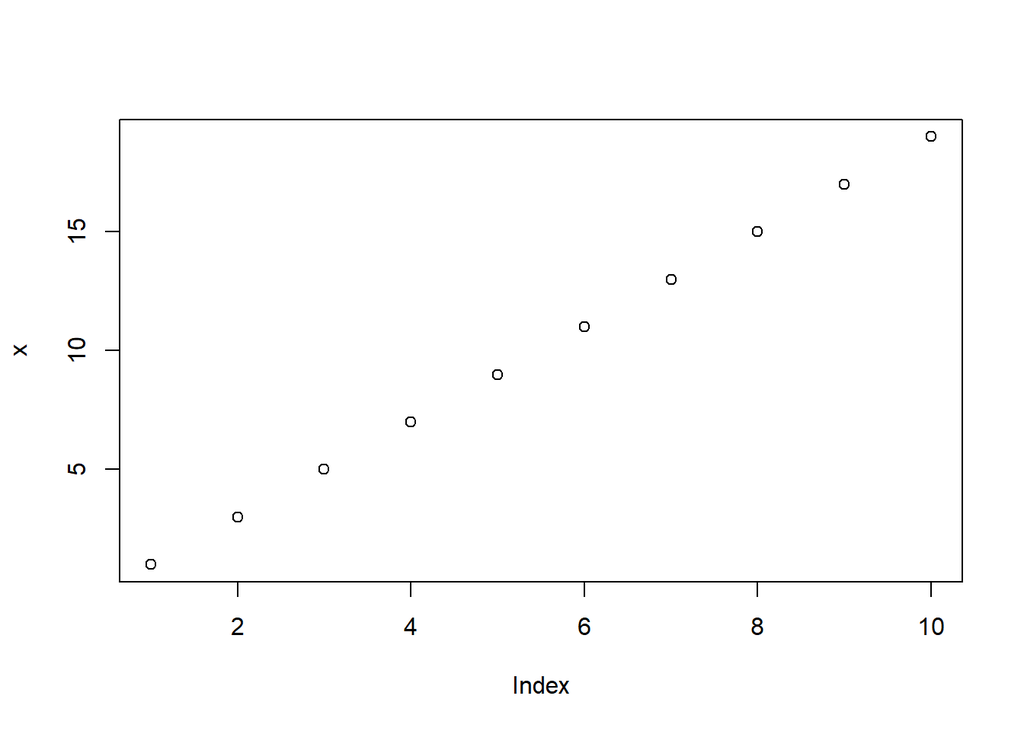

```r
x<-seq(1,20, by=2) # uma serie de dados
plot(x) # somente x
```

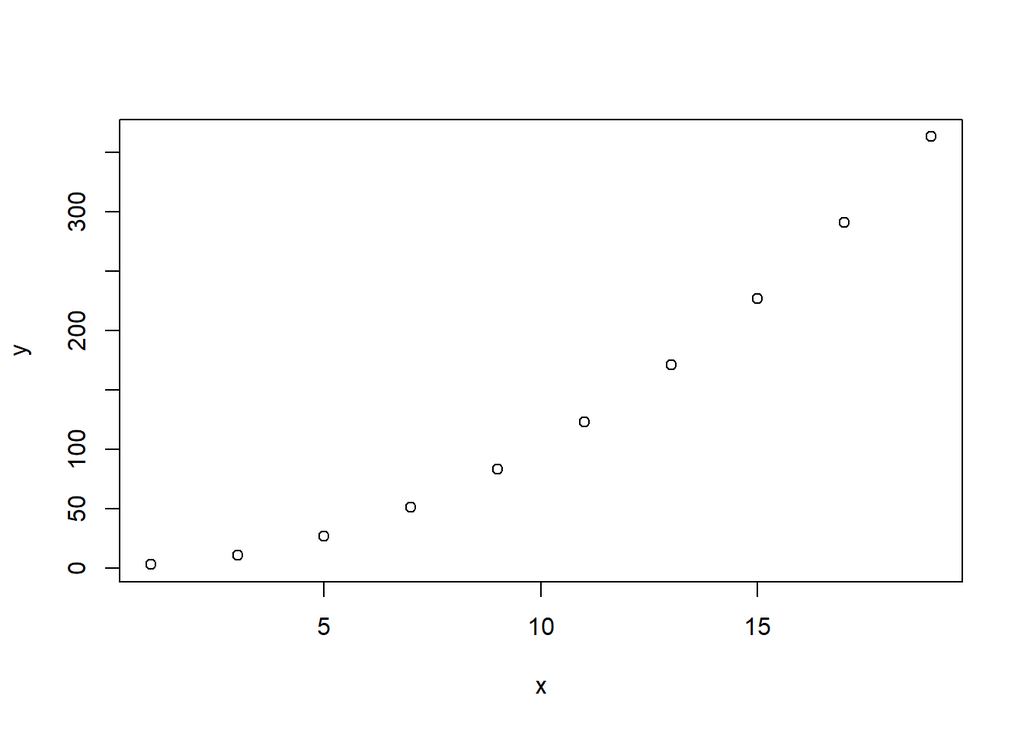

```r
y<- 2+x^2
plot(x,y) # coordenadas x-y
```

O `plot()` pode ser personalizado por meio do ajuste de seus argumentos. A seguir, com os mesmos dados, geram-se gráficos de linhas, com características diferentes.

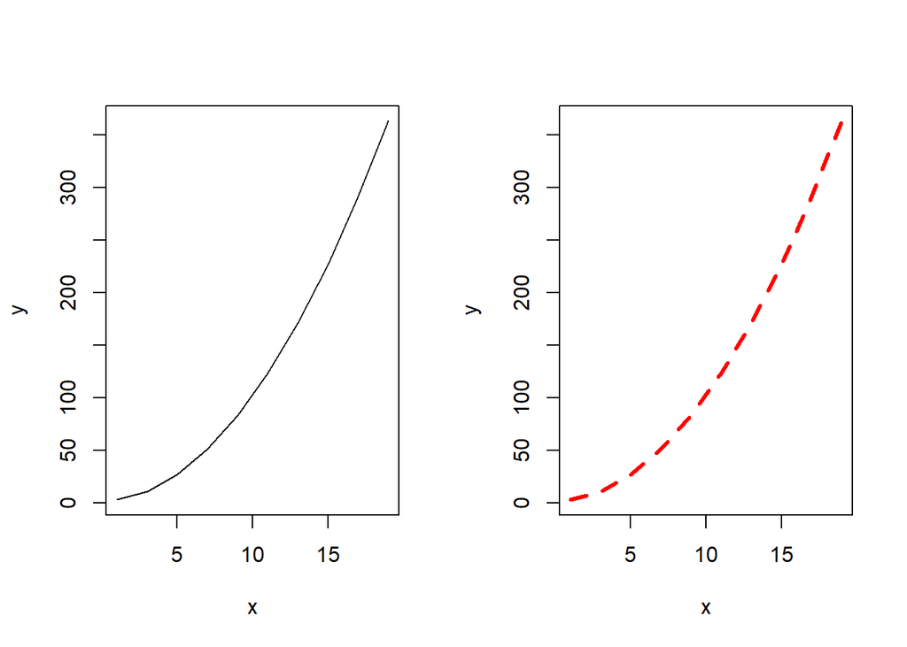

```r
par(mfrow=c(1,2)) # divide a janela gráfica 1 linha e 2 colunas
plot(x,y, type="l") # linha sólida (by default)
plot(x,y, type="l", col="red", lty=2, lwd=3)
```

```r
par(mfrow=c(1,1)) # janela gráfica padrão
```

O R pode gerar o plot gerar oito tipos de plots, controlados pelo argumento `type=`.

Tipos de linhas do plot

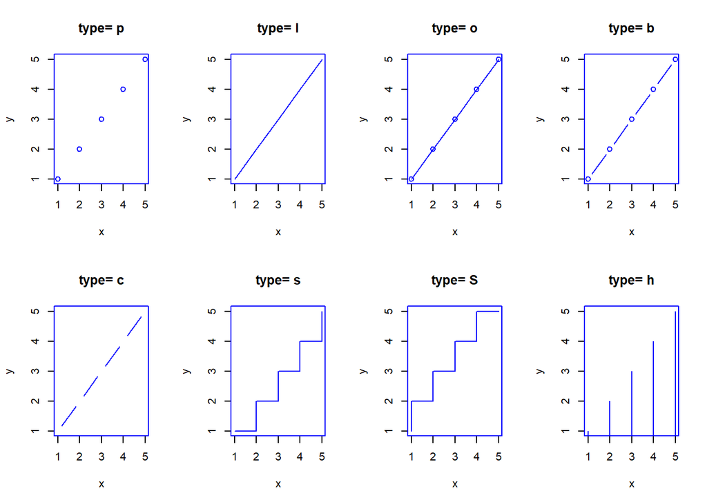

### 5.1.1 Tipos de linhas (*type*)

Há seis tipos de linhas (`type="l"`) disponíveis e configuráveis pelo argumento `lty` listadas a seguir.

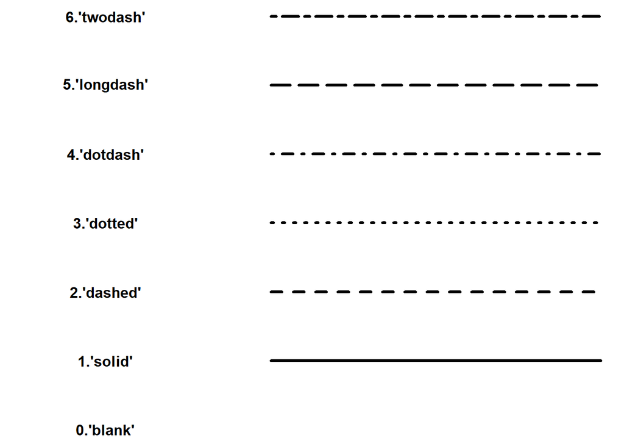

### 5.1.2 Tipos de pontos (*pch*)

Com o argumento `pch`, pode selecionar o tipo de ponto a ser utilizado, simplesmente indicnado o número correspondente ou símbolo desejado. A seguir são exidos os números dos símbolos básicos e alguns adicionais. Para especificar a cor, dos símbolos de 1 a 20, basta usar o argumento, `col=`, todavia, de 21 a 25, o argumento `col=` especifica a cor da borda e `bg=` a cor do preenchimento.

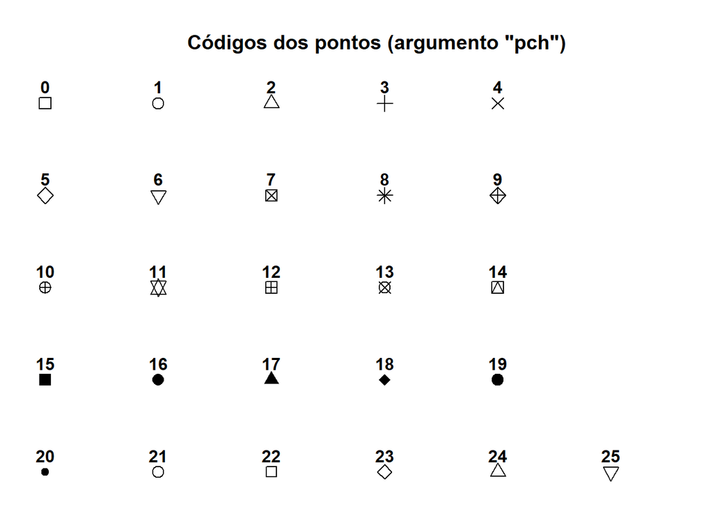

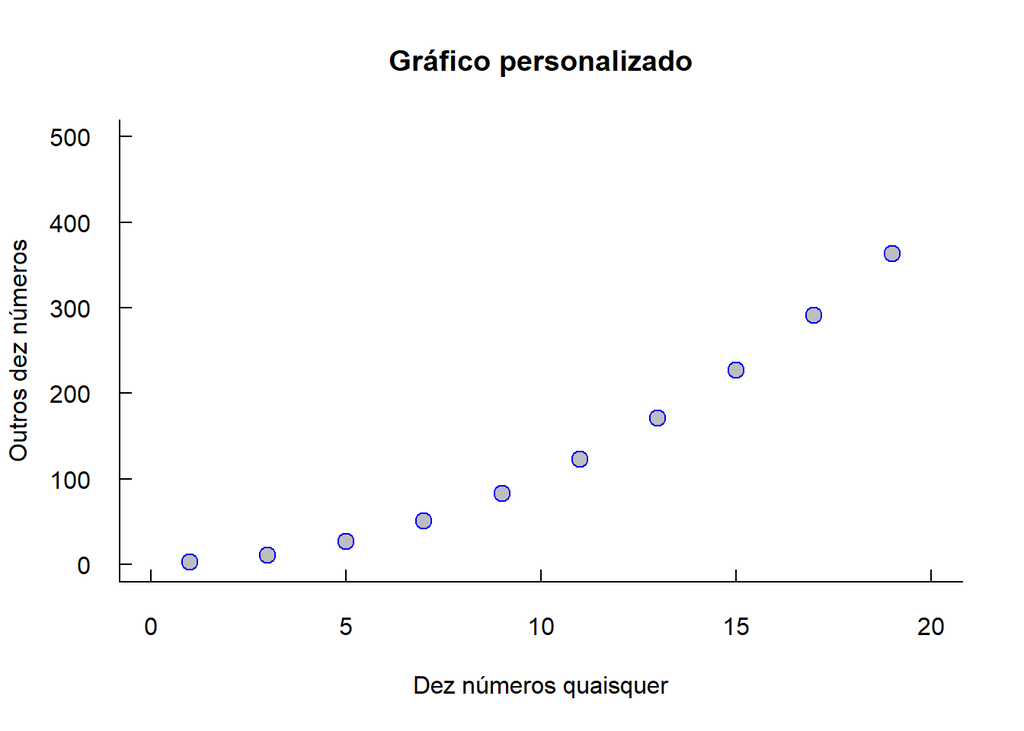

[output not shown]

```r
x<-seq(1,20, by=2) # sequencia
y<- 2+x^2

#  Gráfico de X Y personalizado
plot(x, y, xlab= "Dez números quaisquer", ylab= "Outros dez números", main= "Gráfico personalizado",xlim=c(0,20),ylim=c(0,500),col="blue", pch=21, bg="gray",tcl=0.4,las=1,cex=1.5,bty="L")
```

### 5.1.3 Mais de um conjunto de dados no mesmo gráfico

É possível plotar mais uma linha no mesmo gráfico. No exemplo a seguir, dois conjuntos de dados gerados aleatoriamente com o comando `runif()` e são plotados no mesmo gráfico. O comando `set.seet()` gera uma semente que força os resultados “aleatórios” serem iguais aos aqui demonstrados; caso contrário, os resultaos gerados por `runif()` serão diferentes. O argumento `ann=F` suprime os rótulos dos títulos e eixos e `axes=F` suprime as marcas (*tick marks*) dos eixos de x e y do segundo gráfico.

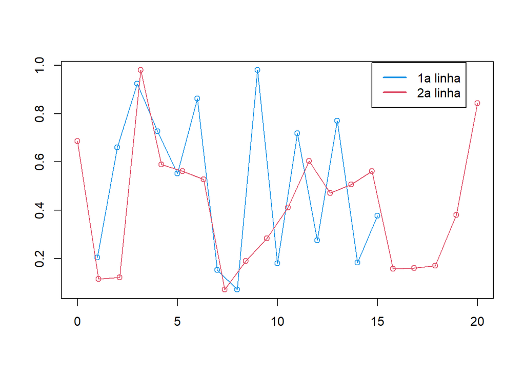

```r
set.seed(652) # semente
plot(runif(15),type="o",ann=F,xlim=c(0,20),col=4)
par(new=T)
set.seed(7174) # semente
plot(runif(20),type="o",ann=F,col=2,axes=F)
legend(15, 1, legend=c("1a linha","2a linha"), lty=c(1,1), col = c(4,2), lwd = 2)
```

A legenda é um componente gráfico adicional.

| Comando e seus parâmetros | Ação |
| --- | --- |
| `legend(15, 1,` | indica as coordenadas horizontal e vertical |
| `legend=c("1a linha","2a linha")` | texto em cada linha |
| `lty=c(1,1)` | Tipo de linha |
| `col = c(4,2)` | cor de cada linha |
| `lwd = 2` | multiplica a espessura das linhas por dois |

A seguir são apresentados outros componentes adicionais.

### 5.1.4 Componentes Gráficos adicionais

Diversos componentes podem ser acrescentados aos gráficos em geral, como linhas, objetos, setas e textos. No quadro abaixo, listam-se os principais.

| Comando | Descrição |
| --- | --- |
| `points(x,y, ...)` | adiciona pontos |
| `lines(x,y, ...)` | adiciona linhas |
| `text(x,y, ...)` | adiciona texto na área de plotagem |
| `abline()` | adiciona linha, horizontal se `h=`; verical se `v=` e em $y=a+bx$ se `a,b` |
| `polygon(x,y, ...)` | adiciona um polígono |
| `segments(x0,y0,x1,y1, ...)` | desenha linhas |
| `arrows(x0,y0,x1,y1, ...)` | desenha setas |
| `symbols(x,y, ...)` | desenha quadrados, círculos, etc. |
| `legend(x,y,legend=, ...)` | adiciona uma legenda |

Os argumentos opcionais definem cores, tamanho e outras características dos elementos adicionados. Esses componentes podem ser demonstrados num gráfico em que são acrescentados livremente apenas para demonstração.

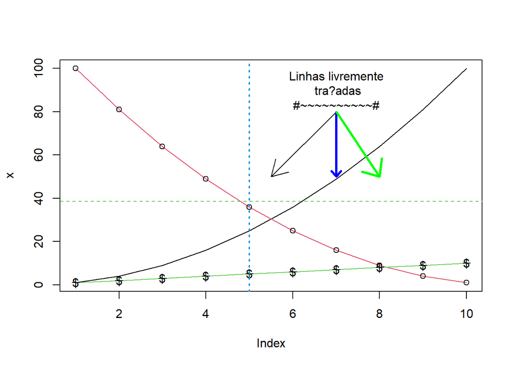

```r
x<-(1:10)^2
plot(x, type="l")
lines(rev(x),col=2)
points(rev(x))
lines(1:10,col=3)
points(1:10,pch=3) #adiciona cruzes
points(1:10,pch="$")#adiciona símbolo $
abline(h=mean(x),col=3, lty="dashed")
abline(v=5,col=4, lty="dotted", lwd=2)
text(7,90, "Linhas livremente\n tra?adas\n#~~~~~~~~~~#")
arrows(7,80,5.5,50)
arrows(7,80,7,50, col="blue",length=0.1,angle=40,lwd=3)
arrows(7,80,8,50, col="green",angle=40,lwd=3)
```

### 5.1.5 Cores

O R possui uma paleta padrão com 8 cores que podem ser acessadas com a função `palette()`, as cores podem ser chamadas pelo nome em ingl?s ou pelo número que designa a sua posição na paleta. as cores são black (preto - 1), red (vermelho - 2), green3 (verde - 3), blue (azul - 4), cyan (ciano - 5), magenta (magenta - 6), yellow (amarelo - 7) e gray (cinza - 8), que podem ser listadas ao se digitar a função `palette()` no console.

As 657 nomes de cores personalizadas disponíveis no R podem ser acessados pelos comandos `colors()`e visualizadas no encarte [Colors in R](http://www.stat.columbia.edu/~tzheng/files/Rcolor.pdf) ou no [R color cheatsheet](https://www.nceas.ucsb.edu/~frazier/RSpatialGuides/colorPaletteCheatsheet.pdf).

```r
palette() # exibe as cores da paleta padrão
colors()  # exibe nomes de 657 cores
```

O R possui 6 grupos ou palestas de cores gradientes:

- rainbow
- heat.colors
- tarrain.colors
- topo.colors
- cm.colors
- gray.colors

```r
x<- -sin(3*pi*((1:20)-1/2)/20)
length(x)
```

```
## [1] 20
```

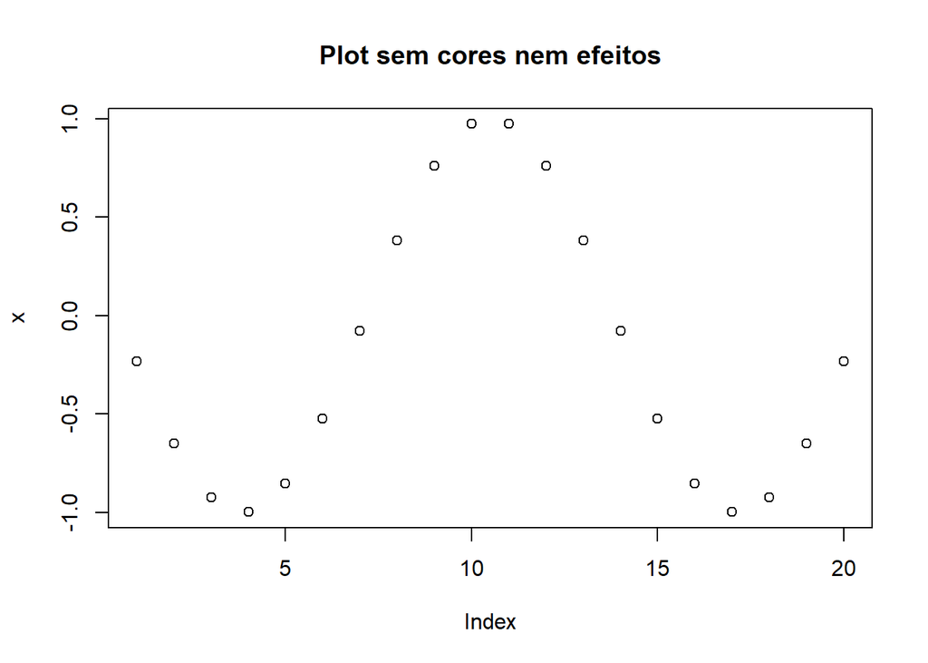

```r
plot(x, pch=21, main = "Plot sem cores nem efeitos")
```

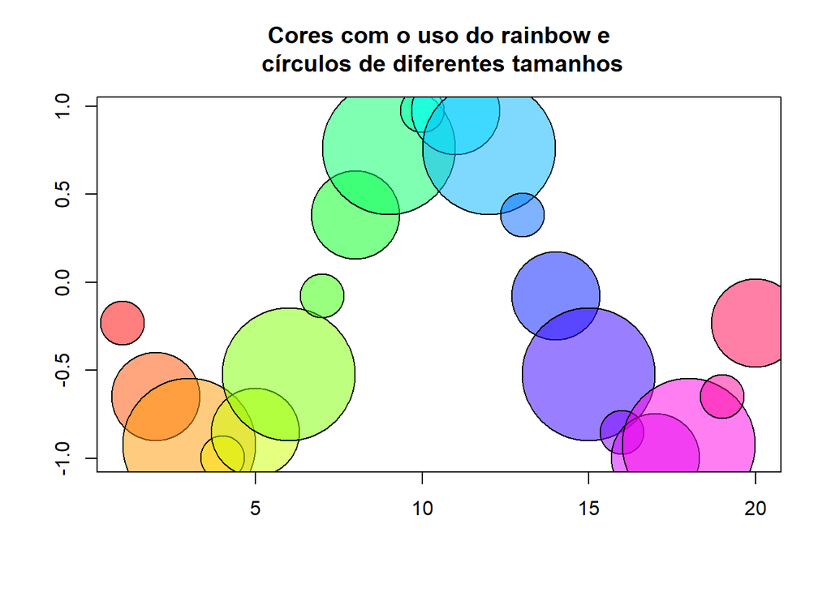

| Comando e seus parâmetros | Ação |
| --- | --- |
| `plot(x` | plota os valores no gráfico |
| `pch=21` | usa o círculo como símbolo de plotagem |
| `cex=c(5,10,15)` | aumenta os tamanhos dos círculos 5, 10, 15 vezes |
| `bg` | cor de preenchimento dos círculos. O uso do argumento `col` com `pch=21` configura as cores da borda dos círculos, não o seu preenchimento |
| `rainbow(20` | usa 20 cores |
| `start = 0, end = .95` | combinações (matiz) de 0 a 0.95 |
| `alpha` | nível de tranparência |

```r
plot(x, pch=21, cex=c(5,10,15), bg=rainbow(20, start = 0, end = .95, alpha = 0.5),ann = FALSE)
title("Cores com o uso do rainbow e\n círculos de diferentes tamanhos")
```

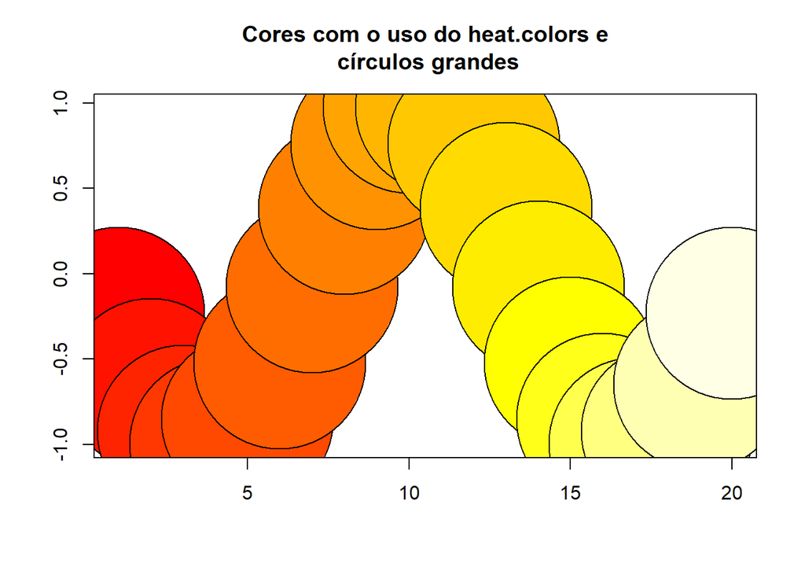

```r
plot(x, pch=21, cex=20, bg=heat.colors(20),ann = FALSE)
title("Cores com o uso do heat.colors e\n círculos grandes")
```

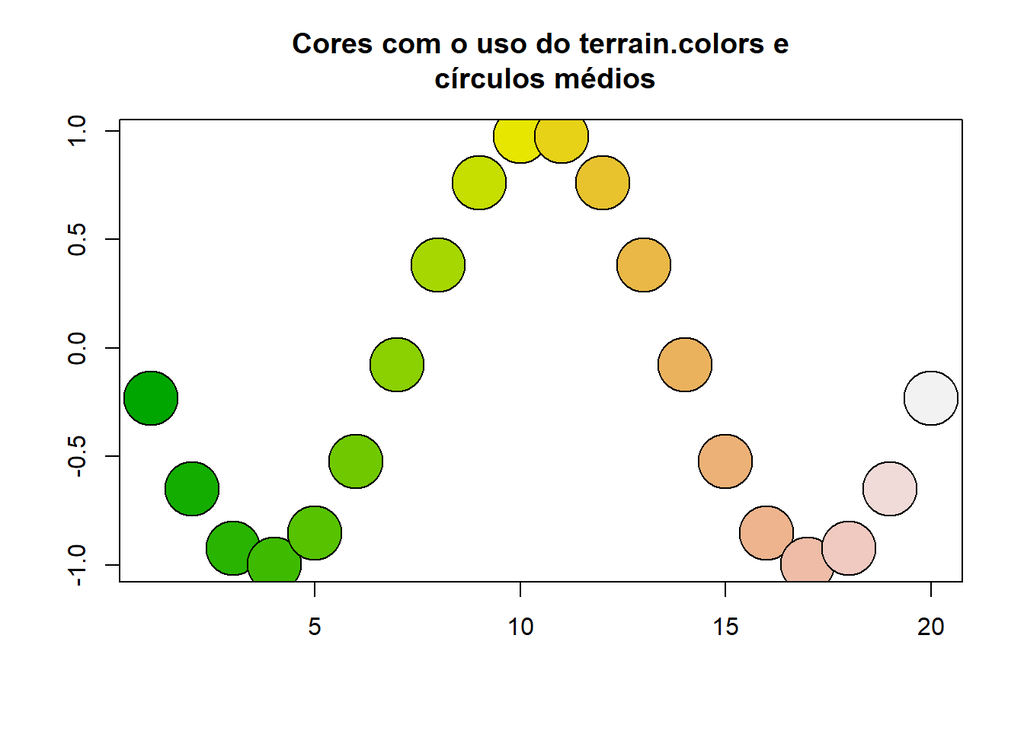

```r
plot(x, pch=21, cex=5, bg=terrain.colors(20),ann = FALSE)
title("Cores com o uso do terrain.colors e\n círculos médios")
```

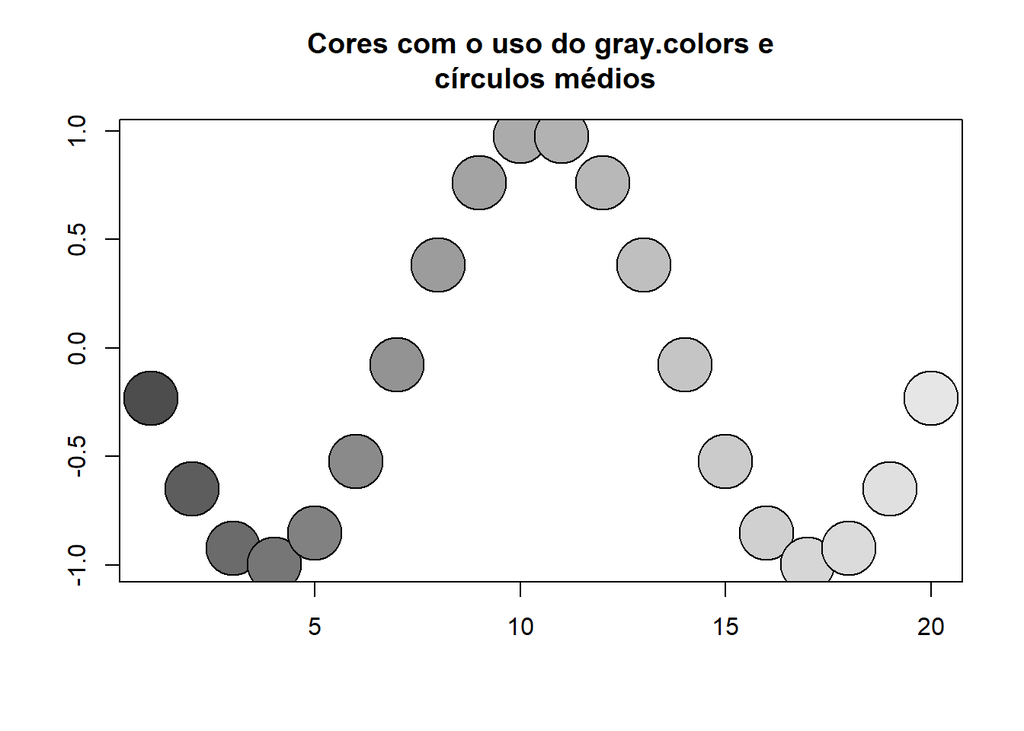

```r
plot(x, pch=21, cex=5, bg=gray.colors(20),ann = FALSE)
title("Cores com o uso do gray.colors e\n círculos médios")
```

## 5.2 Exercício de cores

- Experimente as paletas `topo.colors` e `cm.colors` no gráfico anterior

## 5.3 Gráfico de barras (Barplot)

O comando `barplot()` lê dados de vetores, com ou sem nome dos dados; de modo que basta criar um vetor com o comando `c()`. É possível deixar o gráfico sem rótulos das colunas, como no gráfico da esquerda, ou acrescentar com o argumento `names.arg`.

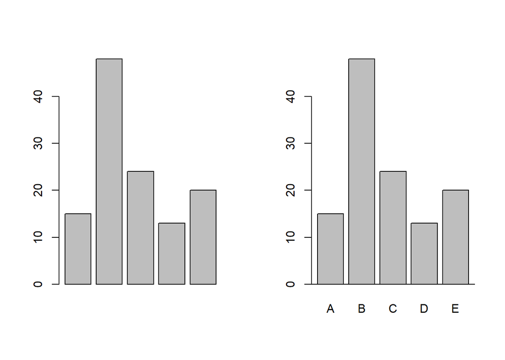

```r
par(mfrow=c(1,2)) # divide a janela gráfica 2 linhas e 2 colunas

x<-c(15,48,24,13,20)
barplot(x)
barplot(x, names.arg = c("A", "B","C","D","E"))
abline(h=0)       # linha horizontal
```

```r
par(mfrow=c(1,1)) # janela gráfica padrão
```

Se o vetor tivesse os nomes dos dados, esses seriam automaticamente inseridos.

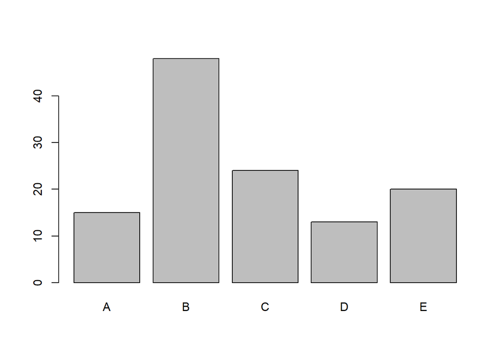

```r
names(x)<-LETTERS[1:5]
barplot(x)
```

O `barplot` faz uma parceria muito útil com as tabelas como no exemplo a seguir criadas com o comando `table()` e preenchidas com o argumento `density =`:

```r
x<-table(rep(c(LETTERS[1:5]), c(15,48,24,13,20)))
x
```

```
##
##  A  B  C  D  E
## 15 48 24 13 20
```

[figure not shown]

```r
barplot(x,density = 6, col="violetred4")
```

### 5.3.1 Títulos, rótulos dos eixos e tamanho das fontes

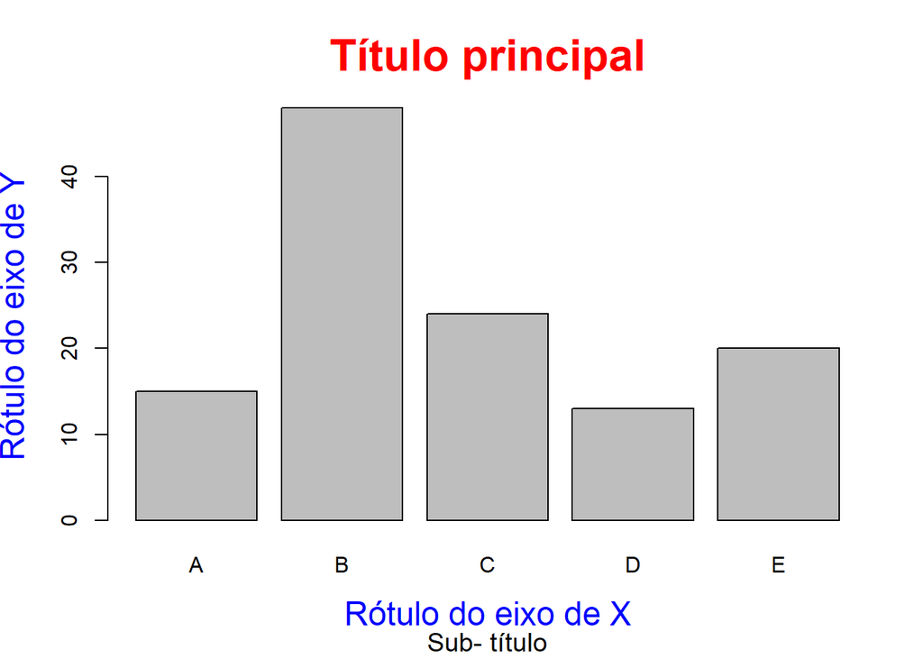

```r
# Adiciona títulos e rótulos
barplot(x, main="Título principal",
        xlab="Rótulo do eixo de X",
        ylab="Rótulo do eixo de Y",
        sub="Sub- título",
        col.main="red", col.lab="blue", col.sub="black",
        cex.main=2, cex.lab=1.5, cex.sub=1.2)
```

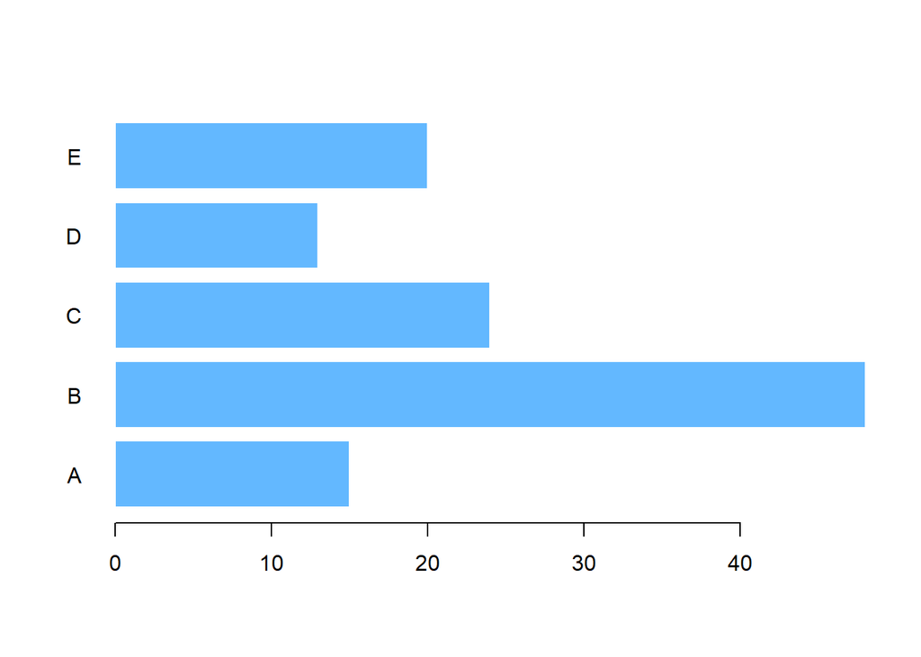

```r
barplot(x, horiz = TRUE,las=1, col="steelblue1", border = F)
```

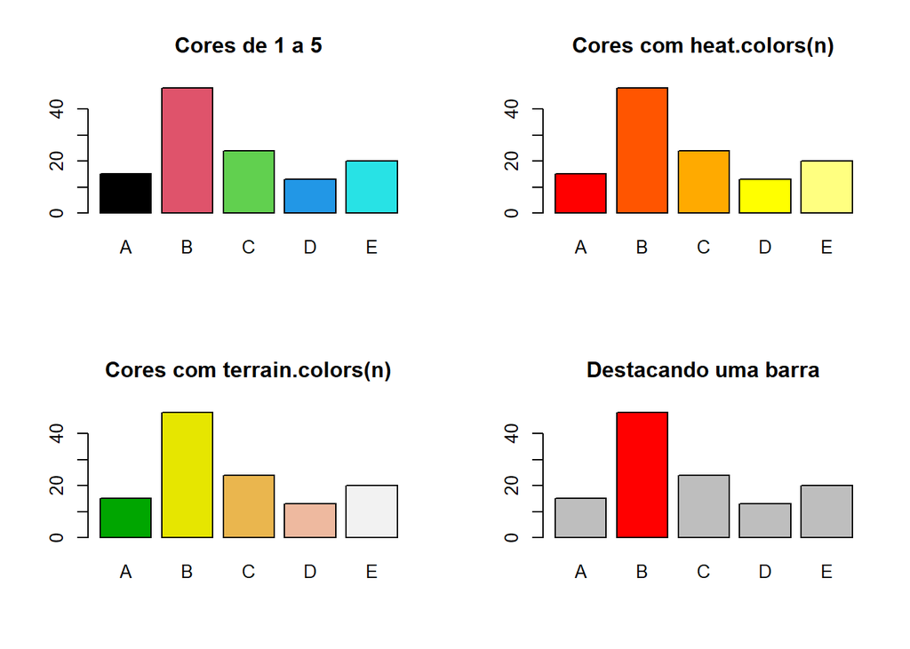

```r
par(mfrow=c(2,2)) # divide a janela gráfica 2 linhas e 2 colunas
barplot(x, col = 1:5, main = "Cores de 1 a 5")
barplot(x, col = heat.colors(5), main = "Cores com heat.colors(n)")
barplot(x, col = terrain.colors(5),main = "Cores com terrain.colors(n)")
barplot(x, col = c("grey","red","grey","grey","grey"),main = "Destacando uma barra")
```

```r
par(mfrow=c(1,1)) # janela gráfica padrão
```

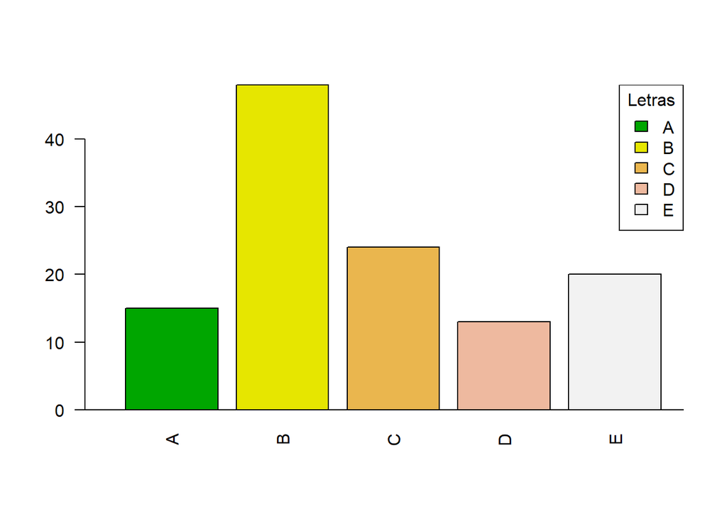

```r
barplot(x,col=terrain.colors(5),xlim=c(0,6),las=2)
legend("topright",legend=rownames(x),fill=terrain.colors(5),title="Letras")
abline(h=0)
```